# FML_Assign 5

Nitin Marwah

2024-04-07

```r
library(tidyr)
library(readr)
library(knitr)
library(dplyr)
library(stats)
library(dbscan)
library(ISLR)
library(caret)
library(cluster)
library(factoextra)
library(tidyverse)
Cereals <- read.csv("/Applications/Cereals.csv")
summary (Cereals)
```

```
##      name               mfr                type              calories
##  Length:77          Length:77          Length:77          Min.   : 50.0
##  Class :character   Class :character   Class :character   1st Qu.:100.0
##  Mode  :character   Mode  :character   Mode  :character   Median :110.0
##                                                           Mean   :106.9
##                                                           3rd Qu.:110.0
##                                                           Max.   :160.0
##
##     protein           fat            sodium          fiber
##  Min.   :1.000   Min.   :0.000   Min.   :  0.0   Min.   : 0.000
##  1st Qu.:2.000   1st Qu.:0.000   1st Qu.:130.0   1st Qu.: 1.000
##  Median :3.000   Median :1.000   Median :180.0   Median : 2.000
##  Mean   :2.545   Mean   :1.013   Mean   :159.7   Mean   : 2.152
##  3rd Qu.:3.000   3rd Qu.:2.000   3rd Qu.:210.0   3rd Qu.: 3.000
##  Max.   :6.000   Max.   :5.000   Max.   :320.0   Max.   :14.000
##
##      carbo          sugars           potass          vitamins
##  Min.   : 5.0   Min.   : 0.000   Min.   : 15.00   Min.   :  0.00
##  1st Qu.:12.0   1st Qu.: 3.000   1st Qu.: 42.50   1st Qu.: 25.00
##  Median :14.5   Median : 7.000   Median : 90.00   Median : 25.00
##  Mean   :14.8   Mean   : 7.026   Mean   : 98.67   Mean   : 28.25
##  3rd Qu.:17.0   3rd Qu.:11.000   3rd Qu.:120.00   3rd Qu.: 25.00
##  Max.   :23.0   Max.   :15.000   Max.   :330.00   Max.   :100.00
##  NA's   :1      NA's   :1        NA's   :2
##      shelf           weight          cups           rating
##  Min.   :1.000   Min.   :0.50   Min.   :0.250   Min.   :18.04
##  1st Qu.:1.000   1st Qu.:1.00   1st Qu.:0.670   1st Qu.:33.17
##  Median :2.000   Median :1.00   Median :0.750   Median :40.40
##  Mean   :2.208   Mean   :1.03   Mean   :0.821   Mean   :42.67
##  3rd Qu.:3.000   3rd Qu.:1.00   3rd Qu.:1.000   3rd Qu.:50.83
##  Max.   :3.000   Max.   :1.50   Max.   :1.500   Max.   :93.70
##
```

```r
head(Cereals)
```

```
##                        name mfr type calories protein fat sodium fiber carbo
## 1                 100%_Bran   N    C       70       4   1    130  10.0   5.0
## 2         100%_Natural_Bran   Q    C      120       3   5     15   2.0   8.0
## 3                  All-Bran   K    C       70       4   1    260   9.0   7.0
## 4 All-Bran_with_Extra_Fiber   K    C       50       4   0    140  14.0   8.0
## 5            Almond_Delight   R    C      110       2   2    200   1.0  14.0
## 6   Apple_Cinnamon_Cheerios   G    C      110       2   2    180   1.5  10.5
##   sugars potass vitamins shelf weight cups   rating
## 1      6    280       25     3      1 0.33 68.40297
## 2      8    135        0     3      1 1.00 33.98368
## 3      5    320       25     3      1 0.33 59.42551
## 4      0    330       25     3      1 0.50 93.70491
## 5      8     NA       25     3      1 0.75 34.38484
## 6     10     70       25     1      1 0.75 29.50954
```

```r
#Scaling the dataset
Scaled_Cereals <- Cereals
Scaled_Cereals[ , c(4:16)] <- scale(Cereals[ , c(4:16)])
#Eliminating the NA values from the data collection using Omit function
Preprocessed_Cereal <- na.omit(Scaled_Cereals)
head(Preprocessed_Cereal)
```

```
##                        name mfr type   calories    protein         fat
## 1                 100%_Bran   N    C -1.8929836  1.3286071 -0.01290349
## 2         100%_Natural_Bran   Q    C  0.6732089  0.4151897  3.96137277
## 3                  All-Bran   K    C -1.8929836  1.3286071 -0.01290349
## 4 All-Bran_with_Extra_Fiber   K    C -2.9194605  1.3286071 -1.00647256
## 6   Apple_Cinnamon_Cheerios   G    C  0.1599704 -0.4982277  0.98066557
## 7               Apple_Jacks   K    C  0.1599704 -0.4982277 -1.00647256
##       sodium       fiber      carbo     sugars     potass   vitamins      shelf
## 1 -0.3539844  3.29284661 -2.5087829 -0.2343906  2.5753685 -0.1453172  0.9515734
## 2 -1.7257708 -0.06375361 -1.7409943  0.2223705  0.5160205 -1.2642598  0.9515734
## 3  1.1967306  2.87327158 -1.9969238 -0.4627711  3.1434645 -0.1453172  0.9515734
## 4 -0.2346986  4.97114672 -1.7409943 -1.6046739  3.2854885 -0.1453172  0.9515734
## 6  0.2424445 -0.27354112 -1.1011705  0.6791317 -0.4071355 -0.1453172 -1.4507595
## 7 -0.4136273 -0.48332864 -0.9732057  1.5926539 -0.9752315 -0.1453172 -0.2495930
##       weight       cups     rating
## 1 -0.1967771 -2.1100340  1.8321876
## 2 -0.1967771  0.7690100 -0.6180571
## 3 -0.1967771 -2.1100340  1.1930986
## 4 -0.1967771 -1.3795303  3.6333849
## 6 -0.1967771 -0.3052601 -0.9365625
## 7 -0.1967771  0.7690100 -0.6756899
```

After pre-processing and scaling, the total number of observations was 74 instead of 77. Only three records had the value NA.

Question 1-: Apply hierarchical clustering to the data using Euclidean distance to the normalized measure- ments. Use Agnes to compare the clustering from single linkage, complete linkage, average linkage, and Ward. Choose the best method.

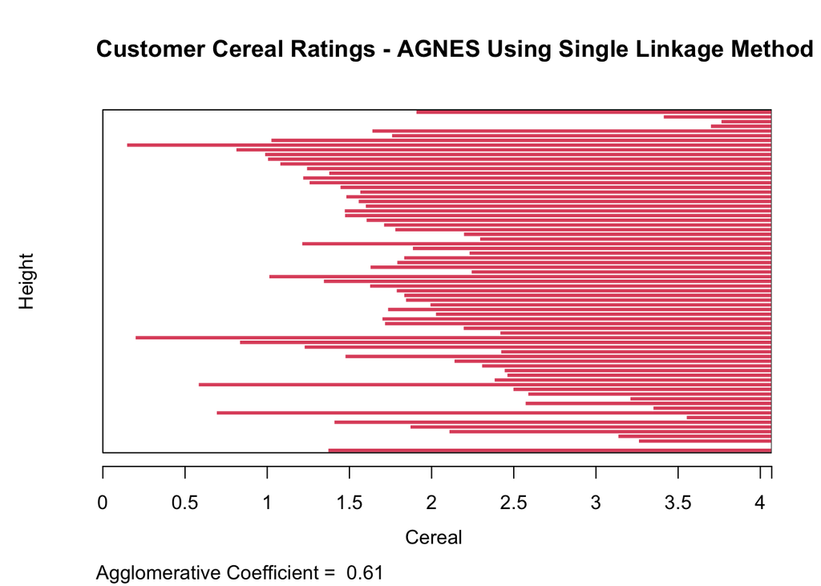

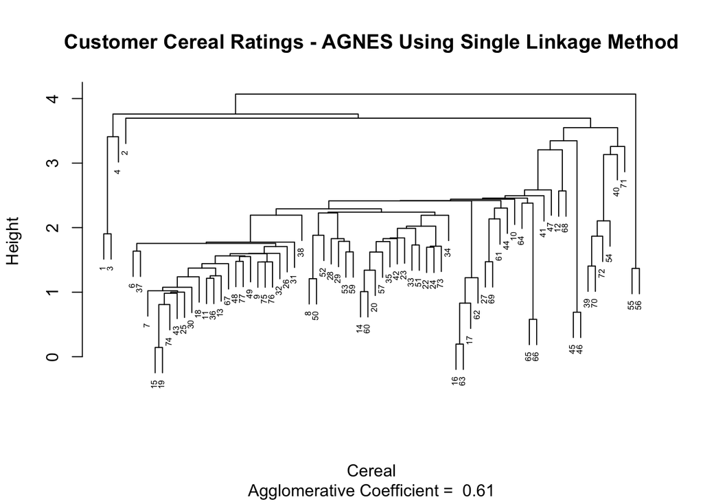

```r
#Applying Dissimilarity matrix
Cereal_Euclidean <- dist(Preprocessed_Cereal[ , c(4:16)], method = "euclidean")
# Applying Single linkage method
Single <- agnes(Cereal_Euclidean, method = "single")
plot(Single,
main = "Customer Cereal Ratings - AGNES Using Single Linkage Method",
xlab = "Cereal",
ylab = "Height",
cex.axis = 1,
cex = 0.50)
```

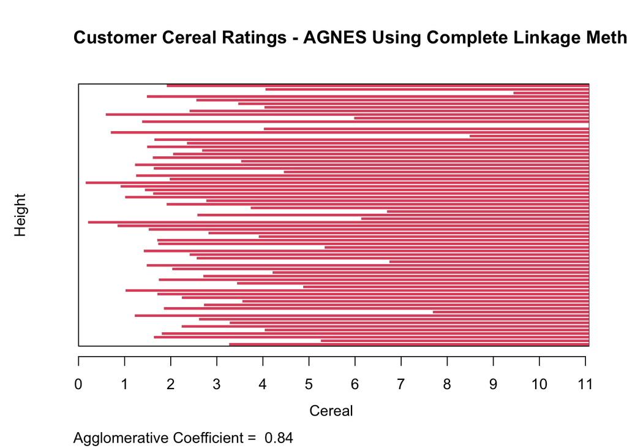

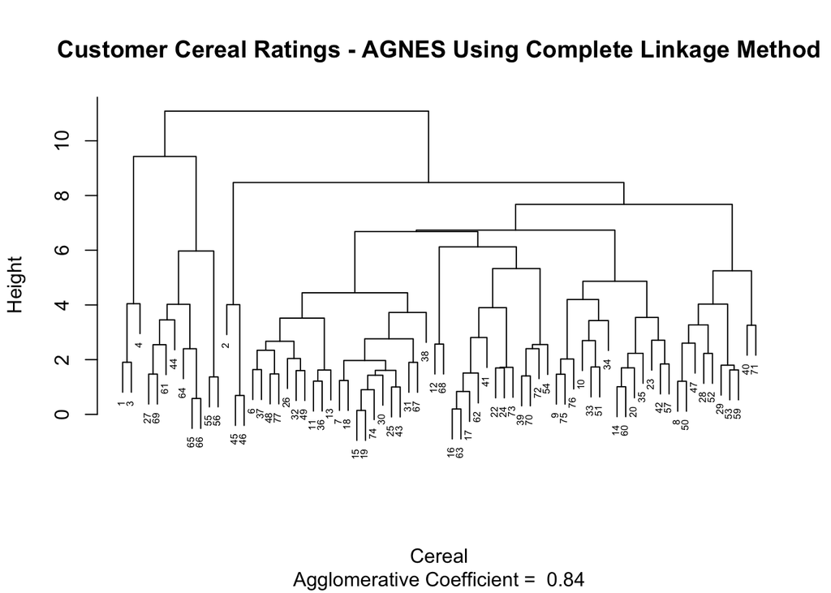

```r
#Applying Complete linkage
Complete <- agnes(Cereal_Euclidean, method = "complete")
plot(Complete,
main = "Customer Cereal Ratings - AGNES Using Complete Linkage Method", xlab = "Cereal",
ylab = "Height",
cex.axis = 1,
cex = 0.50)
```

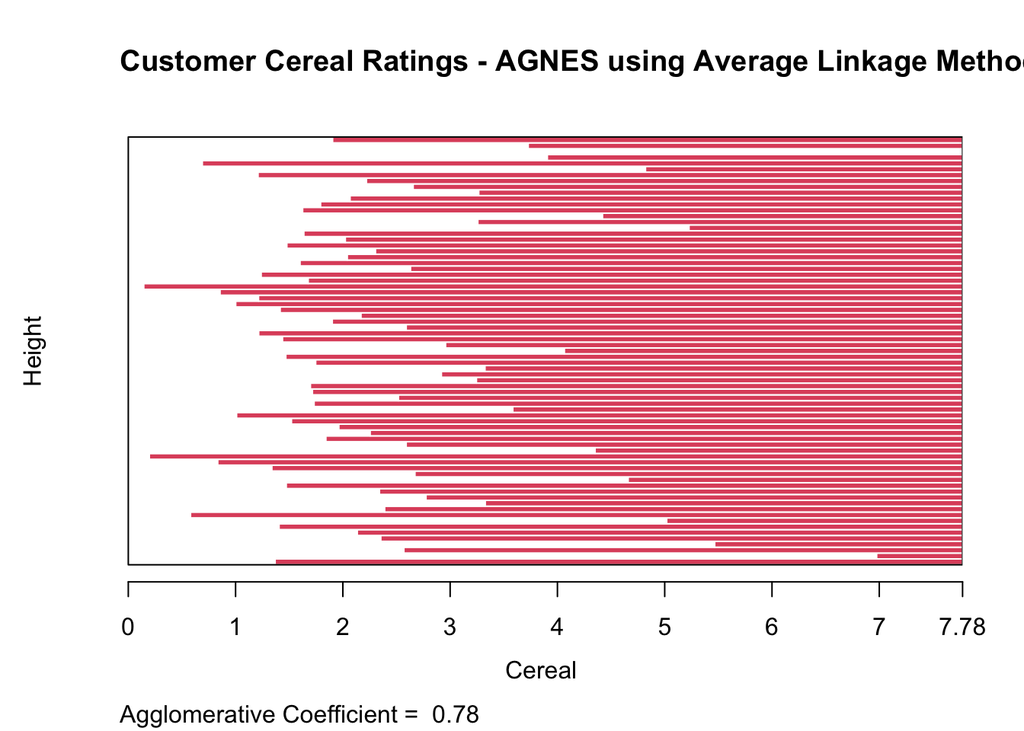

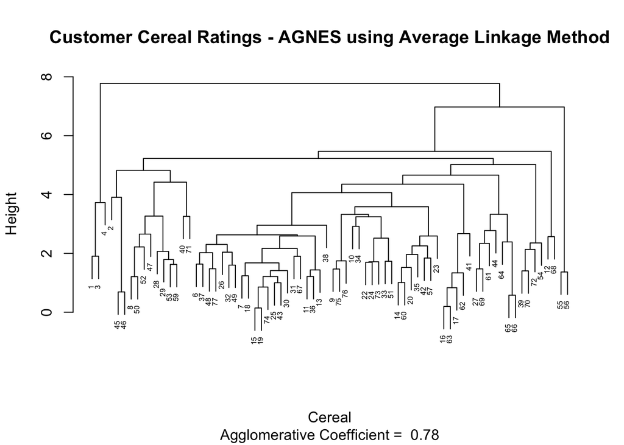

```r
#Applying Average linking method
Average <- agnes(Cereal_Euclidean, method = "average")
plot(Average,
main = "Customer Cereal Ratings - AGNES using Average Linkage Method", xlab = "Cereal",
ylab = "Height",
cex.axis = 1,
cex = 0.50)
```

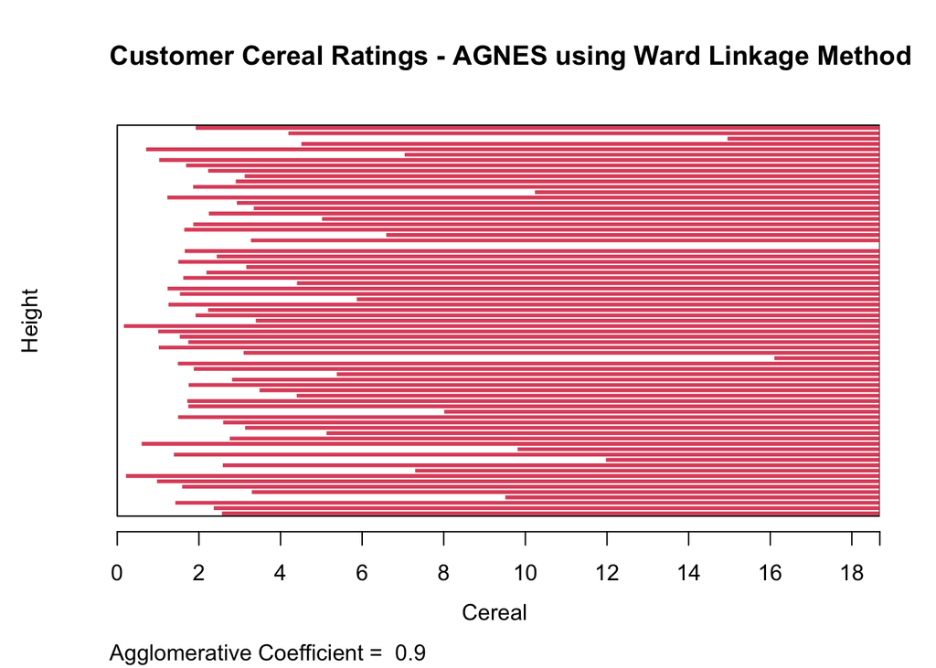

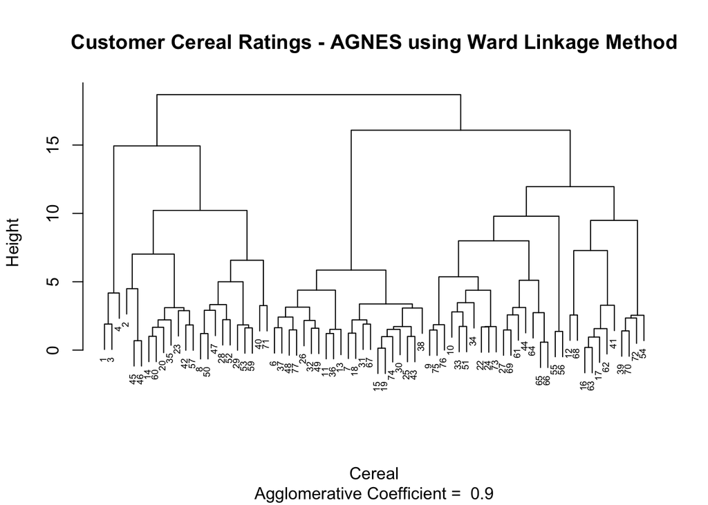

```r
#Applying Ward linkage method
Ward <- agnes(Cereal_Euclidean, method = "ward")
plot(Ward,
main = "Customer Cereal Ratings - AGNES using Ward Linkage Method", xlab = "Cereal",
ylab = "Height",
cex.axis = 1,
cex = 0.55)
```

As the value approaches 1.0, the clustering structure becomes closer. Therefore, the approach with the value closest to 1.0 is chosen. Among the approaches, only Linkage scored 0.61, Total Linkage scored 0.84, Average connection scored 0.78, and Ward Approach scored 0.90. Based on the data, the Ward technique emerges as the most effective clustering strategy in this scenario.

Question 2-: How many clusters would you choose?

In this analysis, I am determining the optimal number of clusters using the elbow and silhouette methods.

1. Elbow Technique-:

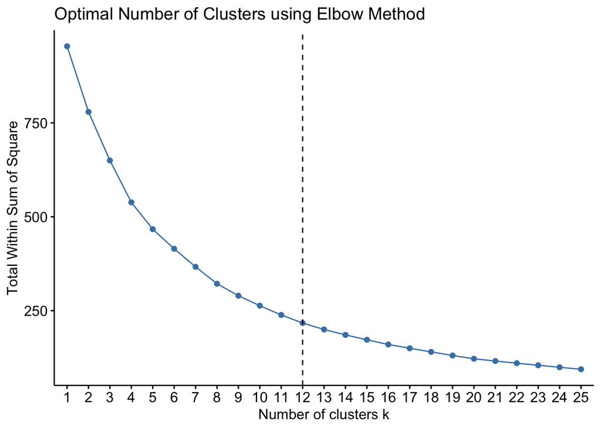

```r
fviz_nbclust(Preprocessed_Cereal[ , c(4:16)], hcut, method = "wss", k.max = 25) + labs(title = "Optimal Number of Clusters using Elbow Method") + geom_vline(xintercept = 12, linetype = 2)
```

(B) Silhouette Technique-:

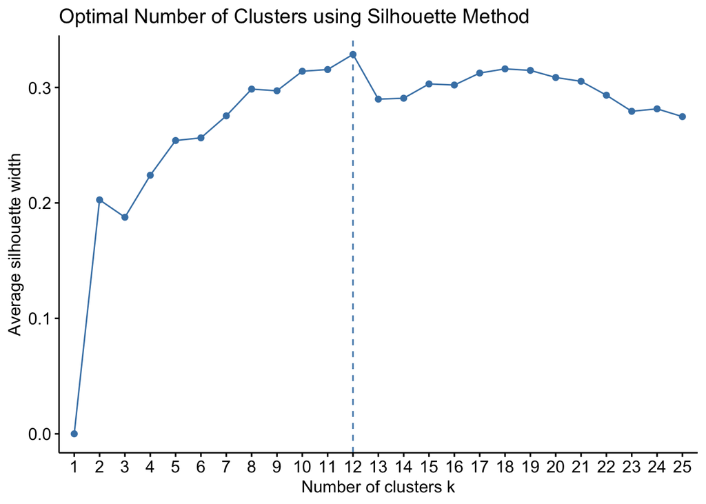

```r
fviz_nbclust(Preprocessed_Cereal[ , c(4:16)], hcut,
method = "silhouette",
k.max = 25) +
labs(title = "Optimal Number of Clusters using Silhouette Method")
```

The outcomes of the elbow and silhouette methods suggest that 12 clusters would be the ideal number.

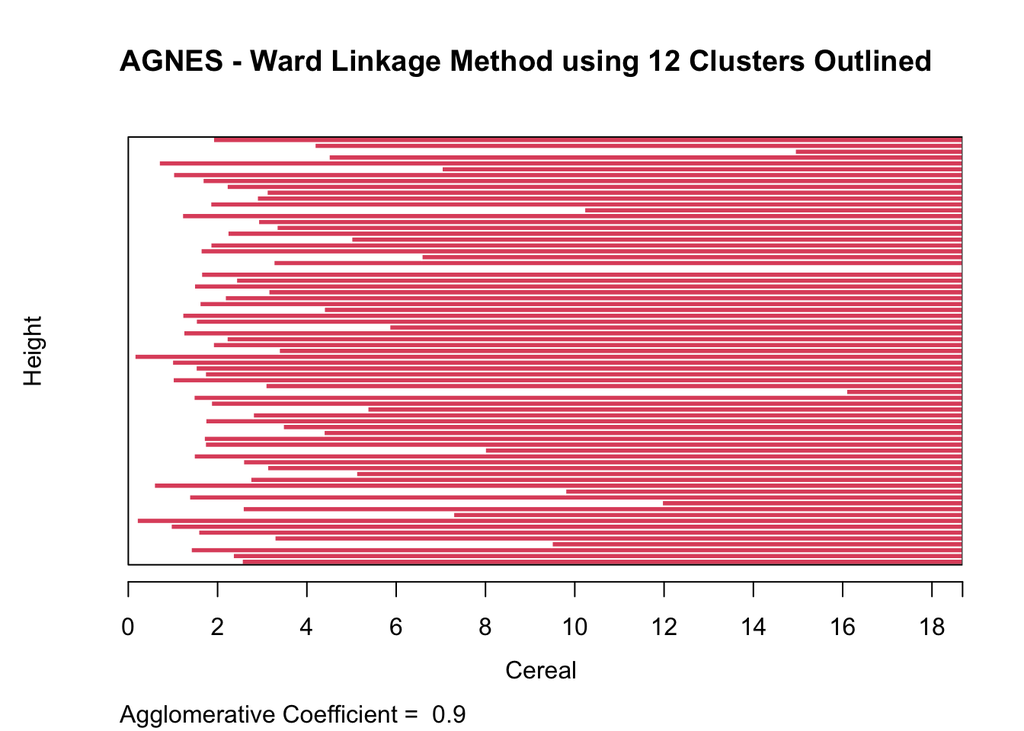

```r
#Plotting the ward hierarchical tree with 12 groups highlighted
plot(Ward,
     main = "AGNES - Ward Linkage Method using 12 Clusters Outlined",
     xlab = "Cereal",
     ylab = "Height",
     cex.axis = 1,
cex = 0.50,)
```

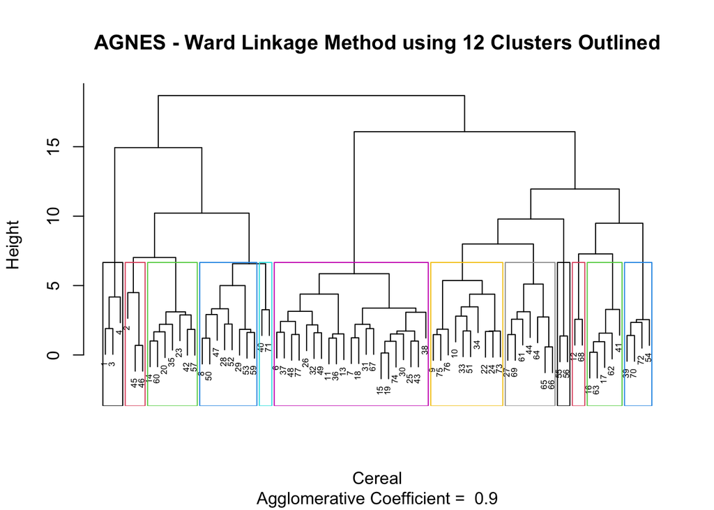

```r
rect.hclust(Ward, k = 12, border = 1:12)
```

Question 2-: Comment on the structure of the clusters and on their stability. Hint: To check stability,partition the data and see how well clusters formed based on one part apply to the other part. To do this: ● Cluster partition A ● Use the cluster centroids from A to assign each record in partition B (each record is assigned to the cluster with the closest centroid). ● Assess how consistent the cluster assignments are compared to the assignments based on all the data.

```r
# Partitioning data into 2 groups- A & B
set.seed(66)
part.A <- Preprocessed_Cereal[1:55, 4:16]
part.B <- Preprocessed_Cereal[56:74, 4:16]
# Conducting hierarchical clustering with K=12
sin.df <- agnes(scale(part.A), method = "single")
comp.df <- agnes(scale(part.A), method = "complete")
avg.df <- agnes(scale(part.A), method = "average")
ward.df <- agnes(scale(part.A), method = "ward")
ward.df.2 <- agnes(scale(part.B), method = "ward")

cbind(single=sin.df$ac, complete=comp.df$ac, average=avg.df$ac, ward=ward.df$ac)
```

```
##         single  complete   average      ward
## [1,] 0.6564842 0.8120228 0.7449303 0.8808195
```

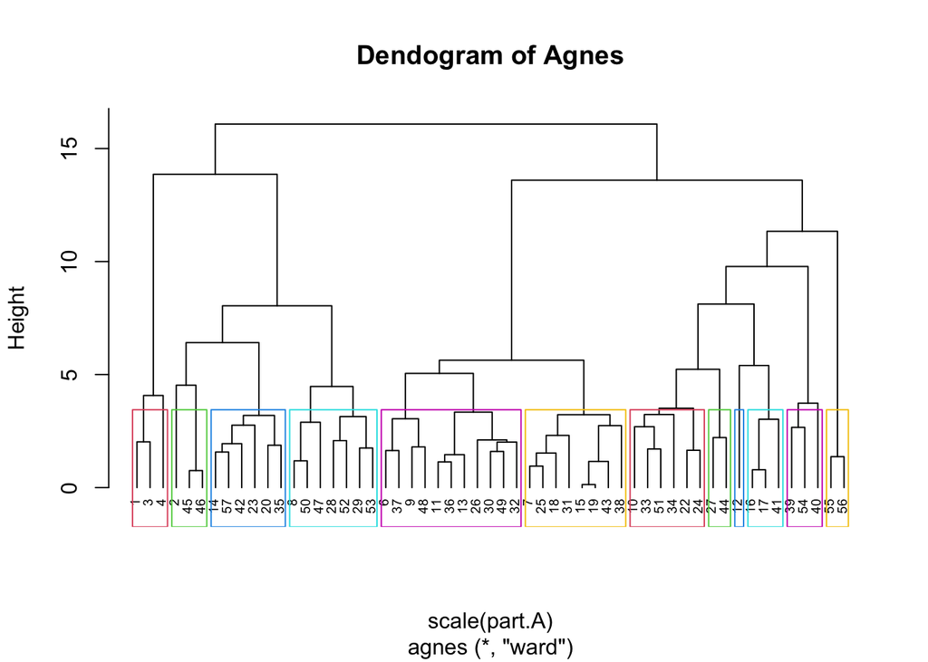

```r
pltree(ward.df, cex = 0.6, hang = -1, main = "Dendogram of Agnes")
rect.hclust(ward.df, k = 12, border = 2:7)
```

Creating 4 Centroids

```r
df.2 <- cutree(ward.df, k=12)
df.3 <- cutree(ward.df.2,k=12)
df_2 <- as.data.frame(cbind(df.3,part.B))
```

```r
outcome.df <- as.data.frame(cbind(part.A, df.2))
outcome.df[outcome.df$df.2==1,]
```

```
##    calories  protein         fat     sodium    fiber     carbo     sugars
## 1 -1.892984 1.328607 -0.01290349 -0.3539844 3.292847 -2.508783 -0.2343906
## 3 -1.892984 1.328607 -0.01290349  1.1967306 2.873272 -1.996924 -0.4627711
## 4 -2.919461 1.328607 -1.00647256 -0.2346986 4.971147 -1.740994 -1.6046739
##     potass   vitamins     shelf     weight      cups   rating df.2
## 1 2.575368 -0.1453172 0.9515734 -0.1967771 -2.110034 1.832188    1
## 3 3.143464 -0.1453172 0.9515734 -0.1967771 -2.110034 1.193099    1
## 4 3.285488 -0.1453172 0.9515734 -0.1967771 -1.379530 3.633385    1
```

```r
# Centroid A
cent.A <- colMeans(outcome.df[outcome.df$df.2==1,])
outcome.df[outcome.df$df.2==2,]
```

```
##     calories   protein      fat     sodium       fiber      carbo    sugars
## 2  0.6732089 0.4151897 3.961373 -1.7257708 -0.06375361 -1.7409943 0.2223705
## 45 2.2129244 1.3286071 1.974235 -0.7714846  0.35582142  0.3064419 0.9075122
## 46 2.2129244 1.3286071 1.974235 -0.1154129  0.35582142  0.3064419 0.9075122
##       potass   vitamins     shelf     weight    cups     rating df.2
## 2  0.5160205 -1.2642598 0.9515734 -0.1967771 0.76901 -0.6180571    2
## 45 1.0131045 -0.1453172 0.9515734 -0.1967771 0.76901 -0.3935878    2
## 46 1.0131045 -0.1453172 0.9515734 -0.1967771 0.76901 -0.6069456    2
```

```r
# Centroid B
cent.B <- colMeans(outcome.df[outcome.df$df.2==2,])
outcome.df[outcome.df$df.2==3,]
```

```
##      calories    protein         fat     sodium       fiber       carbo
## 6   0.1599704 -0.4982277  0.98066557  0.2424445 -0.27354112 -1.10117049
## 9  -0.8665066 -0.4982277 -0.01290349  0.4810160  0.77539645  0.05051241
## 11  0.6732089 -1.4116451  0.98066557  0.7195875 -0.90290366 -0.71727619
## 13  0.6732089 -1.4116451  1.97423464  0.6003018 -0.90290366 -0.46134666
## 26  0.1599704 -1.4116451 -1.00647256  0.4810160 -0.48332864 -0.20541712
## 30  0.1599704 -1.4116451 -0.01290349 -0.2943415 -0.90290366 -0.46134666
## 32  0.1599704 -1.4116451 -0.01290349  1.4353022 -0.90290366  0.05051241
## 36  0.6732089 -1.4116451  0.98066557  0.7195875 -0.48332864 -0.71727619
## 37  0.1599704  0.4151897 -0.01290349  1.0774449 -0.27354112 -0.84524095
## 48 -0.3532681 -0.4982277 -0.01290349  0.7195875 -0.06375361  0.05051241
## 49  0.6732089 -0.4982277 -0.01290349  0.3617302 -0.90290366  0.05051241
##        sugars     potass   vitamins     shelf     weight       cups     rating
## 6   0.6791317 -0.4071355 -0.1453172 -1.450759 -0.1967771 -0.3052601 -0.9365625
## 9  -0.2343906  0.3739965 -0.1453172 -1.450759 -0.1967771 -0.6490266  0.4594871
```

[output cut: 21 more lines]

```r
# Centroid C
cent.C <- colMeans(outcome.df[outcome.df$df.2==3,])
outcome.df[outcome.df$df.2==4,]
```

```
##      calories    protein         fat     sodium      fiber      carbo    sugars
## 7   0.1599704 -0.4982277 -1.00647256 -0.4136273 -0.4833286 -0.9732057 1.5926539
## 15  0.1599704 -1.4116451 -0.01290349  0.2424445 -0.9029037 -0.7172762 1.3642734
## 18  0.1599704 -1.4116451 -1.00647256 -0.8311275 -0.4833286 -0.4613467 1.1358928
## 19  0.1599704 -1.4116451 -0.01290349  0.2424445 -0.9029037 -0.7172762 1.3642734
## 25  0.1599704 -0.4982277 -0.01290349 -0.4136273 -0.4833286 -0.9732057 1.3642734
## 31 -0.3532681 -0.4982277 -1.00647256 -1.3679135 -0.9029037 -0.9732057 1.8210345
## 38  0.1599704 -1.4116451 -1.00647256  0.2424445 -0.9029037 -0.2054171 0.9075122
## 43  0.1599704 -0.4982277 -0.01290349  0.2424445 -0.9029037 -0.7172762 1.1358928
##        potass   vitamins     shelf     weight      cups     rating df.2
## 7  -0.9752315 -0.1453172 -0.249593 -0.1967771 0.7690100 -0.6756899    4
## 15 -0.6201715 -0.1453172 -0.249593 -0.1967771 0.7690100 -1.4187264    4
## 18 -1.1172554 -0.1453172 -0.249593 -0.1967771 0.7690100 -0.4899817    4
## 19 -0.4781475 -0.1453172 -0.249593 -0.1967771 0.7690100 -1.4429256    4
## 25 -0.9752315 -0.1453172 -0.249593 -0.1967771 0.7690100 -0.7444941    4
## 31 -0.8332075 -0.1453172 -1.450759 -0.1967771 0.2533603 -0.5277361    4
## 38 -0.9042195 -0.1453172 -1.450759 -0.1967771 2.1870466 -0.9911728    4
## 43 -0.6201715 -0.1453172 -0.249593 -0.1967771 0.7690100 -1.1341114    4
```

```r
# Centroid D
cent.D <- colMeans(outcome.df[outcome.df$df.2==4,])

cent <- rbind(cent.A, cent.B, cent.C, cent.D)
df.2 <- as.data.frame(rbind(cent[,-14], part.B))
```

Calculating the Distance

```r
Distance.A <- get_dist(df.2)
Mat.A <- as.matrix(Distance.A)

dataf <- data.frame(data=seq(1, nrow(part.B), 1), Clusters= rep(0, nrow(part.B)))
for(i in 1:nrow(part.B))
  {dataf[i,2] <- which.min(Mat.A[i+4, 1:4])}
dataf
```

```
##    data Clusters
## 1     1        3
## 2     2        3
## 3     3        3
## 4     4        3
## 5     5        3
## 6     6        4
## 7     7        3
## 8     8        3
## 9     9        4
## 10   10        3
## 11   11        4
## 12   12        3
## 13   13        2
## 14   14        3
## 15   15        3
## 16   16        4
## 17   17        3
## 18   18        3
## 19   19        3
```

```r
cbind(df_2$part.3, dataf$Clusters)
```

```
##       [,1]
##  [1,]    3
##  [2,]    3
##  [3,]    3
##  [4,]    3
##  [5,]    3
##  [6,]    4
##  [7,]    3
##  [8,]    3
##  [9,]    4
## [10,]    3
## [11,]    4
## [12,]    3
## [13,]    2
## [14,]    3
## [15,]    3
## [16,]    4
## [17,]    3
## [18,]    3
## [19,]    3
```

Finally, assessing cluster stability through comparison-:

```r
table(df_2$df.3==dataf$Clusters)
```

```
##
## FALSE  TRUE
##    18     1
```

Findings-: Therefore, it exhibits high instability due to the limited number of “TRUE” values.

Question 4-:The elementary public schools would like to choose a set of cereals to include in their daily cafeterias. Every day a different cereal is offered, but all cereals should support a healthy diet. For this goal, you are requested to find a cluster of “healthy cereals.” Should the data be normalized? If not, how should they be used in the cluster analysis?

```r
# Clustering "Healthy Cereals"
Nutri_c <- Preprocessed_Cereal[,c("calories", "protein", "fat", "fiber", "carbo", "sugars", "potass", "vitamins")]
# Normalizing already completed, hence no repeatation required.
# Applying Euclidean method
range <- dist(Nutri_c, method = "euclidean")

hc <- hclust(range, method = "ward.D2")
```

```r
# With K=12, we are required to create 12 clusters for this dataset.
Preprocessed_Cereal$cluster = cutree(hc, k = 12)
# Selecting Numeric columns
num.data = Preprocessed_Cereal[, sapply(Preprocessed_Cereal, is.numeric)]
# Creating cluster summary
c_sum <- aggregate(. ~ cluster, data = num.data, FUN = mean)
c_sum
```

```
##    cluster    calories     protein         fat      sodium      fiber
## 1        1 -2.23514255  1.32860712 -0.34409318  0.20268253  3.7124216
## 2        2  0.50212944  0.41518972  2.63661401 -0.99017518  0.3558214
## 3        3  0.15997044  0.11071726  0.64947588  0.12315869 -0.1336828
## 4        4  0.24551019 -1.05642719 -0.06810178  0.06351580 -0.7397356
## 5        5  2.00762903  0.78055668  1.37809320  0.06351580  0.2719064
## 6        6 -0.62699526  0.04982277 -0.67528287 -0.51700829  0.3558214
## 7        7 -0.14797266  2.05934104  0.18581032  0.01580149 -0.3154986
## 8        8  0.08665066 -0.62871587 -0.72259568  1.21377145 -0.7830251
## 9        9  0.67320894  0.41518972 -0.01290349  0.51083744  1.2998652
## 10      10 -0.09664881 -0.04151897 -0.26129576  0.74940899 -0.3784349
## 11      11  1.69968594  0.41518972 -0.01290349  0.24244446  0.3558214
## 12      12 -2.91946055 -0.95493637 -1.00647256 -1.90469943 -0.6931161
##          carbo     sugars      potass   vitamins      shelf     weight
## 1  -2.08223369 -0.7672786  3.00144048 -0.1453172  0.9515734 -0.1967771
```

[output cut: 24 more lines]

Final Result-: Normalizing already completed, hence no repeatation required.